# Session 3 – Microbiome–Diet-SCFA Co-occurrence Network

SPIEC-EASI networks of metagenome abundance and SCFAs

## Introduction

In the DIME paper, co-occurrence networks were built from high-dimensional PFAM protein family abundances and faecal metabolomics peaks. This takes a bit of time and introduces two kinds of data that we haven’t seen before (the functional data, PFams, which are Protein Families, and raw metabolomics data).

Here we build the same type of network from scratch on the data we have been using today, which is much smaller. SPIEC-EASI is meant for compositional data, so using it on the targeted SCFA data is not really appropriate (however, it’s not invalid, but the data will be treated compositionally though it is absolute, so it is not optimal).

- **Matrix A** - microbiome features (same species OTU table as sessions 1 & 2)
- **Matrix B** - SCFAs

We’ll run **SPIEC-EASI** on these two matrices, which jointly produces a network where edges can connect species to species, species to SCFAs, or SCFAs-SCFAs.

After that, we’ll draw the network using the `igraph` package and if there’s time, analyse network features with the NetCoMi package.

## 1 Load packages

```r
library(tidyverse)
library(igraph)     # igraph::degree, betweenness, neighborhood, subgraph, …
library(SpiecEasi)  # SpiecEasi::spiec.easi, getOptCov, getRefit
library(NetCoMi)    # NetCoMi::netConstruct, netAnalyze, netCompare, diffnet

source("../R/data.R")    # read_metadata(), read_taxa(), order_table()
source("../R/theme.R")   # BIOACTIVE_COLORS, THEME_DIME
```

## 2 Load data

```r
tbl_md <- read_metadata("../data/source/sample_metadata.csv")

# species-level abundance (L5 = species)
tbl_species <- read_taxa("../data/source/microbiome/taxa/MGS.matL6.txt") |>
  order_table()

species_rel <- tbl_species |>
  column_to_rownames(colnames(tbl_species)[1]) |>
  as.matrix() |>
  prop.table(margin = 2)   # relative abundance: columns sum to 1

# SCFAs
tbl_scfa <- read_delim(
  "../data/source/scfa/SCFA_DIME.csv", show_col_types = FALSE
) |> rename(sample_id = ID)
```

## 3 Prepare feature matrices

### 3.1 Filter species abundance to top 75

We select the 75 most abundant species across all post-intervention samples - they account for ~66 % of the community. This is purely to save time; we’re not using an HPC for this, and want it to be done in a few minutes. Ideally, we keep all the species!

```r
# Short name: strip lineage to species only
trim_species <- function(x) {
  parts <- strsplit(x, ";", fixed = TRUE)[[1]]
  known <- parts[parts != "?"]
  tail(known, 1)
}

hb_samples <- tbl_md |>
  filter(sample_arm == "after_high") |>
  pull(sample_id)

lb_samples <- tbl_md |>
  filter(sample_arm == "after_low") |>
  pull(sample_id)

mean_abund  <- rowMeans(species_rel[, c(hb_samples, lb_samples)])
top_species <- names(sort(mean_abund, decreasing = TRUE)[75:0])

cat(length(top_species), "species selected,",
    length(hb_samples), "HB samples,", length(lb_samples), "LB samples\n")
```

```
## 75 species selected, 20 HB samples, 20 LB samples
```

### 3.2 Build the SCFA matrix

**Matrix B** is the matrix of SCFAs.

```r
# SCFAs: align to the same samples
scfa_mat <- tbl_scfa |>
  column_to_rownames("sample_id") |>
  as.matrix()    # samples x SCFAs



cat("SCLFA feature matrix:", nrow(scfa_mat), "samples x", ncol(scfa_mat), "features\n")
```

```
## SCLFA feature matrix: 100 samples x 10 features
```

```r
cat("Features:", paste(colnames(scfa_mat), collapse = ", "), "\n")
```

```
## Features: Acetate, Propionate, Butyrate, Isobutyrate, 2-methylbutyrate,  Isovalerate, Valerate, 3-methylvalerate, Isocaproate, Caproate
```

### 3.3 Align all matrices per arm

SPIEC-EASI requires both matrices to have the same samples in the same row order.

```r
# Matrix A: species relative abundance (samples x species)
mat_species_hb <- t(species_rel[top_species, hb_samples])
mat_species_lb <- t(species_rel[top_species, lb_samples])

# Matrix B: diet features (samples x diet features), same sample order
mat_scfa_hb <- scfa_mat[hb_samples, ]
mat_scfa_lb <- scfa_mat[lb_samples, ]
```

## 4 Run SPIEC-EASI

When `data` is a list of two matrices, `spiec.easi()` fits a model to both jointly: it applies CLR transformation to each matrix separately, then estimates the joint sparse inverse covariance matrix over all features.

To save time we’re using fewer repetitions (10); you might want to increase this. Also, note that I’ve played around with nlambda to get the results to be stable, these could be around 50 for better results. To speed up the process for the tutorial, I’ve set `nlambda` to 20.

```r
se_hb <- SpiecEasi::spiec.easi(
  list(mat_species_hb, mat_scfa_hb),
  method = "glasso",
  lambda.min.ratio = 0.1,
  sel.criterion = 'bstars',
  nlambda  = 20,
  pulsar.params = list(rep.num = 10, ncores = 1, seed = 123)
)



se_lb <- SpiecEasi::spiec.easi(
  list(mat_species_lb, mat_scfa_lb),
  method = "glasso",
  lambda.min.ratio = 0.1,
  sel.criterion = 'bstars',
  nlambda  = 20,
  pulsar.params = list(rep.num = 10, ncores = 1, seed = 1234)
)


cat("HB stability:", SpiecEasi::getStability(se_hb))
```

```
## HB stability: 0.03053221
```

```r
cat("LB stability:", SpiecEasi::getStability(se_lb))
```

```
## LB stability: 0.03628011
```

How long did this step take for you? I found this took less than a minute. However, a higher stability (closer to 0.05) is better.

**Exercise:** change some of the parameters and look up the SPIEC-EASI documentation to find other parameters that could be changes. How different is `method="MB"`?

### Extract sparse association matrices

If you just want to see the unweighted matrices, you can do this simply with `se_hb |> getRefit() |> adj2igraph()`. However, to find the signs of different edges in the association matrix, and their weightings, we need to do a little more work.

```r
# Multiply the partial-correlation matrix by the binary refit mask:
# non-zero entries = edges selected by the stability criterion.
se_to_assoc <- function(se_net) {
  cor_mat <- stats::cov2cor(as.matrix(SpiecEasi::getOptCov(se_net)))
  ass     <- as.matrix(cor_mat * SpiecEasi::getRefit(se_net))
  diag(ass) <- 1
  features <- c(colnames(mat_species_hb), colnames(mat_scfa_hb))
  rownames(ass) <- colnames(ass) <- features
  ass
}



ass_hb <- se_to_assoc(se_hb)
ass_lb <- se_to_assoc(se_lb)

n_edges <- function(a) (sum(a != 0) - nrow(a)) / 2


cat("HB:", nrow(ass_hb), "nodes,", n_edges(ass_hb), "edges\n")
```

```
## HB: 85 nodes, 58 edges
```

```r
cat("LB:", nrow(ass_lb), "nodes,", n_edges(ass_lb), "edges\n")
```

```
## LB: 85 nodes, 80 edges
```

## 5 Plot with `igraph`

This is also pretty complicated code. We take the adjacency matrix and convert it into an igraph format by:

- adding the weighting as a `corr` attribute to edges
- adding an edge colour for positive or negative correlations
- tagging vertices as either a species or a dietary feature

```r
n_species <- ncol(mat_species_hb)   # number of species features (same for both arms)

assoc_to_igraph <- function(ass_mat, n_species_nodes) {
  adj <- ass_mat
  diag(adj) <- 0
  g <- igraph::graph_from_adjacency_matrix(adj != 0, mode = "undirected")

  # Edge attributes
  el <- igraph::as_edgelist(g, names = TRUE)
  igraph::E(g)$corr  <- apply(el, 1, \(e) adj[e[1], e[2]])
  igraph::E(g)$color <- ifelse(igraph::E(g)$corr > 0, "forestgreen", "brown2")

  # Node type: first n_species_nodes vertices are species, rest are diet features
  igraph::V(g)$type <- ifelse(
    match(igraph::V(g)$name, rownames(ass_mat)) <= n_species_nodes,
    "species", "scfa"
  )

  # SCFA - species edges
  igraph::E(g)$inter <- apply(el, 1, \(e) {
    igraph::V(g)[e[1]]$type != igraph::V(g)[e[2]]$type
  })
  g
}

ig_hb <- assoc_to_igraph(ass_hb, n_species)
ig_lb <- assoc_to_igraph(ass_lb, n_species)
```

### Visualise paired network

We do need to run NetCoMi’s `netAnalyze` and `netConstruct` methods to get access to it’s plotting function.

```r
net_pair <- NetCoMi::netConstruct(
  ass_hb, ass_lb,
  dataType    = "partialCorr",
  sparsMethod = "none",
  verbose     = 0
)

net_props <- NetCoMi::netAnalyze(
  net_pair,
  #centrLCC    = FALSE,
  clustMethod = "cluster_fast_greedy",
  hubPar      = "betweenness",
  hubQuant    = 0.95,
  normDeg = TRUE, normBetw = TRUE, normClose = TRUE, normEigen = TRUE
)



# Log2 fold-change for species enrichment direction
lfc <- log2(
  (rowMeans(species_rel[top_species, hb_samples]) + 1e-6) /
  (rowMeans(species_rel[top_species, lb_samples]) + 1e-6)
)
species_col_cat <- case_when(
  lfc >  0.5 ~ "High Bioactive",
  lfc < -0.5 ~ "Low Bioactive",
  TRUE        ~ "Neither"
)

# Diet node colour
diet_col_cat <- setNames(
  rep("Diet feature", ncol(scfa_mat)),
  colnames(scfa_mat)
)

node_col_cat <- c(setNames(species_col_cat, top_species), diet_col_cat)

BIO_COLORS_4 <- c(
  "High Bioactive" = unname(BIOACTIVE_COLORS["High Bioactive"]),
  "Low Bioactive"  = unname(BIOACTIVE_COLORS["Low Bioactive"]),
  "Neither"        = "grey70",
  "SCFA"           = "#f58231"
)

# Short labels: species; trim to species name. diet; keep as-is
short_labels <- c(
  setNames(map_chr(top_species, trim_species), top_species),
  setNames(colnames(scfa_mat), colnames(scfa_mat))
)

# Node shape: circles for species, squares for diet features
node_shape_vec <- c(
  setNames(rep("circle", length(top_species)), top_species),
  setNames(rep("square", ncol(scfa_mat)),       colnames(scfa_mat))
)
```

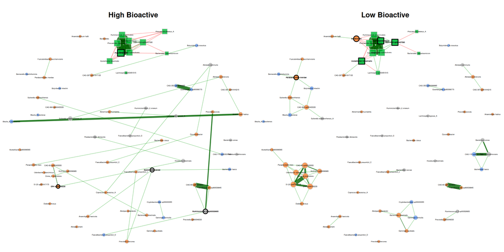

```r
plot(
  net_props,
  sameLayout   = TRUE,
  layoutGroup  = 2,
  rmSingles    = "inboth",
  labels       = short_labels,
  labelScale   = FALSE,
  nodeSize     = "degree",
  cexNodes     = 1,
  nodeSizeSpread = 1.5,
  nodeColor    = "feature",
  colorVec     = unname(BIO_COLORS_4),
  featVecCol   = node_col_cat,
  nodeShape    = c("circle", "square"),
  featVecShape = node_shape_vec,
  nodeTransp   = 20,
  highlightHubs = TRUE,
  cexLabels    = 0.3,
  cexHubLabels = 0.45,
  edgeWidth    = 1.5,
  edgeTranspLow  = 55,
  edgeTranspHigh = 20,
  groupNames   = c("High Bioactive", "Low Bioactive"),
  cexTitle     = 1.2,
  mar          = c(1, 1, 3, 1)
)
```

We can also take a look at some of the network statistics: degree distributions of nodes is plotted below.

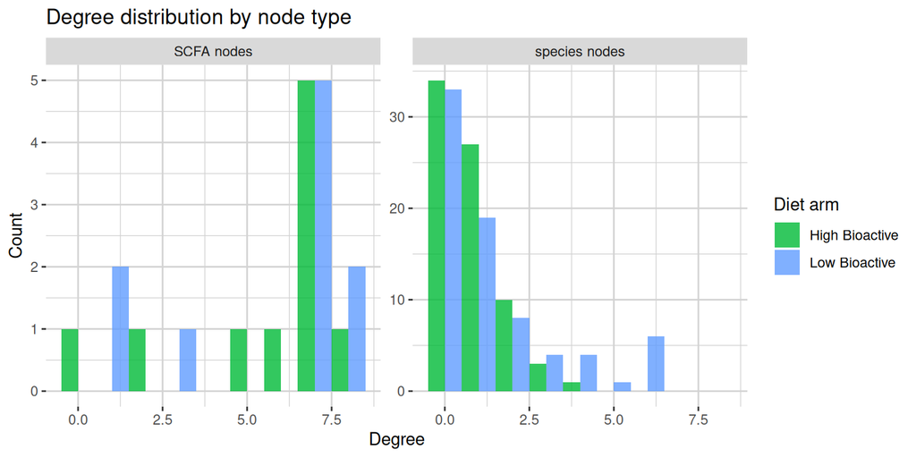

```r
tbl_deg <- bind_rows(
  tibble(node = igraph::V(ig_hb)$name,
         type = igraph::V(ig_hb)$type,
         degree = igraph::degree(ig_hb), arm = "High Bioactive"),
  tibble(node = igraph::V(ig_lb)$name,
         type = igraph::V(ig_lb)$type,
         degree = igraph::degree(ig_lb), arm = "Low Bioactive")
)

ggplot(tbl_deg, aes(x = degree, fill = arm)) +
  geom_histogram(binwidth = 1, position = "dodge", alpha = 0.8) +
  facet_wrap(~type, scales = "free_y",
             labeller = labeller(type = c(species = "species nodes",
                                          scfa  = "SCFA nodes"))) +
  scale_fill_manual(values = BIOACTIVE_COLORS) +
  labs(title = "Degree distribution by node type",
       x = "Degree", y = "Count", fill = "Diet arm") +
  THEME_DIME
```

### Speices-SCFA edges

```r
n_species <- top_species |> length()
n_rows_total <- ass_lb |> rownames() |> length()
rns <- ass_lb[1:n_species, (n_species+1):n_rows_total] |> rownames()
cns <- ass_lb[1:n_species, (n_species+1):n_rows_total] |> colnames()

for (r in rns) {
  for (c in cns) {
    if (ass_lb[r,c] > 0.0001) {
      print(r); print(c); print(ass_lb[r,c])
    }
  }
}
```

```
## [1] "Bacteria;Firmicutes_A;Clostridia;Lachnospirales;Lachnospiraceae;Roseburia;Roseburia intestinalis"
## [1] "Acetate"
## [1] 0.03005906
```

```r
for (r in rns) {
  for (c in cns) {
    if (ass_hb[r,c] > 0.0001) {
      print(r); print(c); print(ass_hb[r,c])
    }
  }
}
```